# Modelling

## Imports

Introduced some models for finding patterns in the data.

Imported multiple packages for data analysis below.

```python
import pandas as pd
import numpy as np
import matplotlib.pyplot as plt

from sklearn.neighbors import KNeighborsClassifier
from sklearn.model_selection import train_test_split, cross_val_score, KFold
from sklearn.feature_extraction.text import CountVectorizer
from sklearn.naive_bayes import MultinomialNB
from sklearn.metrics import accuracy_score
```

## This imports the dataset

Pulls in the data set.

```python
landslides = pd.read_csv('./data/Global_Landslide_Catalog_Export.csv')
```

## Cleans the data

This cleans and manipulates the data from the Exploratory Data Analysis from previous updates.

New however, is the creation of a large text block containing all of the text columns into a single column to allow for easier Natural Language Processing. This new column is called `important_text_to_process`.

```python
landslides['gazeteer_distance'].fillna(0.01, inplace=True)
landslides['admin_division_population'].fillna(0, inplace=True)
landslides['fatality_count'].fillna(0, inplace=True)
landslides['injury_count'].fillna(0, inplace=True)
landslides['gazeteer_closest_point'].fillna('unknown', inplace=True)
landslides['landslide_category'].fillna('unknown', inplace=True)
landslides['landslide_trigger'].fillna('unknown', inplace=True)
landslides['landslide_size'].fillna('unknown', inplace=True)
landslides['landslide_setting'].fillna('unknown', inplace=True)
landslides['country_name'].fillna('unknown', inplace=True)
landslides['admin_division_name'].fillna('unknown', inplace=True)
landslides['event_description'].fillna('unknown', inplace=True)
landslides['event_title'].fillna('unknown', inplace=True)

landslides['event_description'].astype('string')

landslides['r_distance_multiplier'] = np.where((1 / landslides['gazeteer_distance']) > 1, 1, 1 / landslides['gazeteer_distance'])
landslides['fixed_population'] = landslides['admin_division_population'] * landslides['r_distance_multiplier']
landslides['casualties'] = landslides['injury_count'] + landslides['fatality_count']

landslides['important_text_to_process'] = landslides['event_title'] + ' ' +\
landslides['event_description'] + ' ' +\
landslides['admin_division_name'] + ' ' +\
landslides['country_name'] + ' ' +\
landslides['landslide_setting'] + ' ' +\
landslides['landslide_size'] + ' ' +\
landslides['landslide_trigger'] + ' ' +\
landslides['landslide_category'] + ' ' +\
landslides['gazeteer_closest_point']
```

## Finds Null Set

This is the base line result if it were to predict 0 casualties for every single one.

```python
casualty_free = landslides[landslides['casualties'] == 0].count()['casualties']
null_hypothesis = casualty_free/11033

print(f'The percentage of zeros in the casualties column is {null_hypothesis*100:.2f}%')
```

```
The percentage of zeros in the casualties column is 76.40%
```

## Model Testing

Takes the data and randomly splits it in to train and test data.

```python
feature_list = ['important_text_to_process']

X = landslides[feature_list]
y = landslides['casualties']

X_train, X_test, y_train, y_test = train_test_split(X, y)
```

### Attempts Multinomial Naive Bayes

Vectorizes the text column, then applies a Multinomial Naive Bayes model and analyzes using the accuracy score metric, and the cross value score.

```python
important_vect = CountVectorizer(ngram_range=(1,3))
X_train_dtm = important_vect.fit_transform(X_train['important_text_to_process'])
X_test_dtm = important_vect.transform(X_test['important_text_to_process'])
X_dtm = important_vect.transform(X['important_text_to_process'])

important_nb = MultinomialNB()
important_nb.fit(X_train_dtm, y_train)

y_pred = important_nb.predict(X_test_dtm)

print(f'Accuracy Score: {accuracy_score(y_test, y_pred)*100:.2f}%')
cvs = cross_val_score(important_nb, X_dtm, y, cv=KFold(n_splits=5, shuffle=True))

print(f'Average Cross Value Score: {cvs.mean()*100:.2f}%')
```

```
Accuracy Score: 77.60%
Average Cross Value Score: 76.93%
```

### K Nearest Neighbor

Vectorizes the text columns, attempts K Nearest Neighbor modelling, then graphs the k value and score to show about how well it works.

[output not shown]

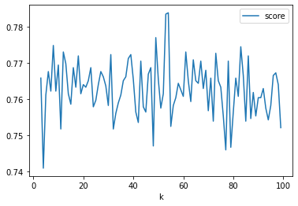

```python
scores = []
for k in range(3,100):
    X_train, X_test, y_train, y_test = train_test_split(X, y, shuffle=True)
    description_vect = CountVectorizer(ngram_range=(1,3))
    X_train_dtm = description_vect.fit_transform(X_train['important_text_to_process'])
    X_test_dtm = description_vect.transform(X_test['important_text_to_process'])
    knn = KNeighborsClassifier(n_neighbors=k)
    knn.fit(X_train_dtm,y_train)
    score = knn.score(X_test_dtm, y_test)
    scores.append([k, score])


scores_array = np.array(scores)
print(f'Predicted Accuracy: {scores_array.mean(axis=0)[1]*100:.2f}%')
print(f'Predicted Highest Accuracy: {np.amax(scores_array, axis=0)[1]*100:.2f}%')
data = pd.DataFrame(scores,columns=['k','score'])
data.plot.line(x='k',y='score');
```

## Conclusions and the Path Forward

More modelling and tuning will need to be done in order to get models to more accurate casualty predictions from the data.